# Coursera DS PML Project

David Vachadze

9 июля 2017 г

## The goal of the project

One thing that people regularly do is quantify how much of a particular activity they do, but they rarely quantify how well they do it. We use data from accelerometers on the belt, forearm, arm, and dumbell of 6 participants. They were asked to perform barbell lifts correctly and incorrectly in 5 different ways. More information is available from the website here: http://groupware.les.inf.puc-rio.br/har The goal of this project is to predict the manner in which they did the exercise. This is the “classe” variable in the training set. You may use any of the other variables to predict with. You should create a report describing how you built your model, how you used cross validation, what you think the expected out of sample error is, and why you made the choices you did. You will also use your prediction model to predict 20 different test cases.

## Data preparation

Let’s first load the data, do some cleaning like selecting meaningfull features, removing NA-only and near zero variance predictors

```r
setwd("~/R/Coursera/r_work/ml/pmla")
library(caret)
pml.train <- read.csv("pml-training.csv", na.strings=c("NA","#DIV/0!",""))
pml.test <- read.csv("pml-testing.csv", na.strings=c("NA","#DIV/0!",""))
pml.test <- pml.test[,8:length(pml.test)] # remove meta-data
pml.train <- pml.train[,8:length(pml.train)] # remove meta-data
t <- apply(pml.train, 2, function(x) sum(is.na(x))/NROW(x)) # check NA percentage in columns
features.names <- names(t[t<0.95]) # leave only columns with less than 95% of NAs
pml.train <- pml.train[,features.names]
pml.test <- pml.test[,features.names[1:length(features.names)-1]]
summary(nearZeroVar(pml.train, saveMetrics = TRUE)[,c(3:4)]) #check if near zero variance data exists to be removed
```

```
##   zeroVar           nzv
##  Mode :logical   Mode :logical
##  FALSE:53        FALSE:53
```

## Model candidates selection

We have multi-class classification problem with relatively large dataset, so we try gbm, random forest and lda We run cross-validation for each model via trainControl caret function, 10-fold 3 repeats, to ensure balanced fitting Than choose best model by means of accuracy

```r
set.seed(1234)
inTrain <- createDataPartition(y=pml.train$classe, p=0.75, list=FALSE)
training <- pml.train[inTrain,]
testing <- pml.train[-inTrain,]
dim(training)
```

```
## [1] 14718    53
```

```r
dim(testing)
```

```
## [1] 4904   53
```

```r
#########################################################################
# the following code takes time to execute, so it wa executed earlier ###
# now I comment it and load sult from previous iteration ################
#########################################################################
#control <- trainControl(method="repeatedcv", number=10, repeats=3)
#set.seed(1234)
#modelLda <- train(classe ~ ., data=training, method="lda", trControl=control)
#set.seed(1234)
#modelGbm <- train(classe ~ ., data=training, method="gbm", trControl=control, verbose=FALSE)
#set.seed(1234)
#modelRf <- train(classe ~ ., data=training, method="rf", trControl=control)
#results <- resamples(list(LDA=modelLda, GBM=modelGbm, RF=modelRf))

#### now load previously saved data ####################################
results <- readRDS("results.RDS")
modelGbm <- readRDS("modelGbm.RDS")
modelRf <- readRDS("modelRf.RDS")
summary(results)
```

```
##
## Call:
## summary.resamples(object = results)
##
## Models: LDA, GBM, RF
## Number of resamples: 30
##
## Accuracy
##          Min.   1st Qu.    Median      Mean   3rd Qu.      Max. NA's
## LDA 0.6714189 0.6931179 0.7032260 0.7014102 0.7083617 0.7273963    0
## GBM 0.9503739 0.9612508 0.9629504 0.9625400 0.9651834 0.9687288    0
## RF  0.9877634 0.9911685 0.9932088 0.9927526 0.9945652 0.9972789    0
##
## Kappa
##          Min.   1st Qu.    Median      Mean   3rd Qu.      Max. NA's
## LDA 0.5842293 0.6116690 0.6243165 0.6220931 0.6311004 0.6543553    0
## GBM 0.9372762 0.9509835 0.9530997 0.9526075 0.9559706 0.9604343    0
## RF  0.9845209 0.9888279 0.9914078 0.9908314 0.9931246 0.9965579    0
```

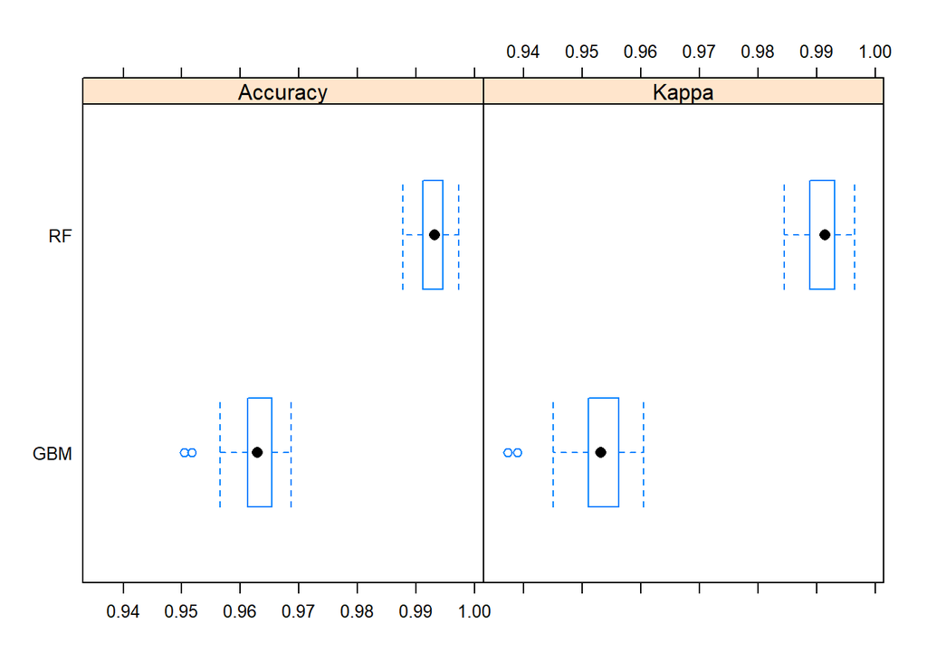

```r
bwplot(resamples(list(GBM=modelGbm, RF=modelRf))) #omit poor LDA model to adjust x scale
```

```r
print(modelRf)
```

```
## Random Forest
##
## 14718 samples
##    52 predictor
##     5 classes: 'A', 'B', 'C', 'D', 'E'
##
## No pre-processing
## Resampling: Cross-Validated (10 fold, repeated 3 times)
## Summary of sample sizes: 13245, 13246, 13247, 13245, 13246, 13247, ...
## Resampling results across tuning parameters:
##
##   mtry  Accuracy   Kappa
##    2    0.9927526  0.9908314
##   27    0.9925263  0.9905454
##   52    0.9887215  0.9857322
##
## Accuracy was used to select the optimal model using  the largest value.
## The final value used for the model was mtry = 2.
```

## Model evaluation

so we see that best model is Random Forest, with 0.9928 accuracy. No we check this model on testing set with known classe for out of sample accuracy

```r
pred_rf <- predict(modelRf, testing)
confusionMatrix(pred_rf, testing$classe)$overall
```

```
##       Accuracy          Kappa  AccuracyLower  AccuracyUpper   AccuracyNull
##      0.9938825      0.9922612      0.9912784      0.9958689      0.2844617
## AccuracyPValue  McnemarPValue
##      0.0000000            NaN
```

We see good results, which means that we have balanced fitting via cross-validation

## Apply winning model to pml testing data

```r
pml.predict <- predict(modelRf, pml.test)
pml.predict
```

```
##  [1] B A B A A E D B A A B C B A E E A B B B
## Levels: A B C D E
```